# Proyecto Final Genómica Funcional

Yaolix & Edox

26/5/2021

#Control & Fiebre

Instalación de los paquetes.

```r
BiocManager :: install ("affy")
```

```
## Bioconductor version 3.11 (BiocManager 1.30.15), R 4.0.2 (2020-06-22)
```

[output not shown]

[output not shown]

```r
BiocManager :: install ("mouse4302cdf")
```

```
## Bioconductor version 3.11 (BiocManager 1.30.15), R 4.0.2 (2020-06-22)
```

[output not shown]

```r
BiocManager :: install ("pvclust")
```

```
## Bioconductor version 3.11 (BiocManager 1.30.15), R 4.0.2 (2020-06-22)
```

[output not shown]

```r
BiocManager :: install ("vsn")
```

```
## Bioconductor version 3.11 (BiocManager 1.30.15), R 4.0.2 (2020-06-22)
```

[output not shown]

```r
BiocManager :: install ("limma")
```

```
## Bioconductor version 3.11 (BiocManager 1.30.15), R 4.0.2 (2020-06-22)
```

[output not shown]

```r
BiocManager :: install ("Biobase")
```

```
## Bioconductor version 3.11 (BiocManager 1.30.15), R 4.0.2 (2020-06-22)
```

[output not shown]

```r
library("affy")
library("mouse4302cdf")
library("pvclust")
library("vsn")
library("Biobase")
library("limma")
```

## Primero cargamos los archivos.

Primero se asigno una dirección donde se encuentran los archivos.CEL, además también la tabla con las muestras que se van a utulizar, en este caso las control y las que tenían la fiebre típica del dengue.

```r
getwd()
```

```
## [1] "C:/Users/HP/Downloads"
```

```r
setwd("C:/Users/HP/Documents/6to semestre/Genómica/Proyecto final/Proyecto/Celulas/")

list.files()
```

```
##  [1] "C1.CEL"                   "C2.CEL"
##  [3] "C3.CEL"                   "C4.CEL"
##  [5] "C5.CEL"                   "COV1.CEL"
##  [7] "COV2.CEL"                 "COV3.CEL"
##  [9] "COV4.CEL"                 "COV5.CEL"
## [11] "expr_normalizadaomg.txt"  "expr_normalizadaomg2.txt"
## [13] "expr_normalizadaomg3.txt" "FD1.CEL"
## [15] "FD2.CEL"                  "FD3.CEL"
## [17] "FD4.CEL"                  "FD5.CEL"
## [19] "FH1.CEL"                  "FH2.CEL"
## [21] "FH3.CEL"                  "FH4.CEL"
## [23] "FH5.CEL"                  "norman.Rdata"
## [25] "pdata.txt"                "pdata2.txt"
## [27] "pdata3.txt"               "pdatacompleta.txt"
```

```r
pd <- read.table("pdata2.txt", header=TRUE, as.is=TRUE)
pd
```

```
##    filename cell type name
## 1    C1.cel   er    C   C1
## 2    C2.cel   er    C   C2
## 3    C3.cel   er    C   C3
## 4    C4.cel   er    C   C4
## 5    C5.cel   er    C   C5
## 6   FD1.cel   er  Fev Fev1
## 7   FD2.cel   er  Fev Fev2
## 8   FD3.cel   er  Fev Fev3
## 9   FD4.cel   er  Fev Fev4
## 10  FD5.cel   er  Fev Fev5
```

```r
##Converción a un archivo AffyData.
#Aquí convertimos lo que es un archivo CEL en uno que sea affy. Aquí también se hace uso de la tabla pd, la que anteriormente contiene como esperamos que se almacenen los datos, usamos los nombres contenidos ahí. En pd estan contenidos los fenotipos y descripciones asociadas a las variables. Les asignamos los nombres a las samples y las cargamos.

affyData <- ReadAffy(filenames = pd$filename)
class(affyData)
```

```
## [1] "AffyBatch"
## attr(,"package")
## [1] "affy"
```

```r
pData(affyData) <- pd
sampleNames(affyData) = pd$name
affyData
```

```
## AffyBatch object
## size of arrays=744x744 features (23 kb)
## cdf=HT_HG-U133_Plus_PM (54715 affyids)
## number of samples=10
## number of genes=54715
## annotation=hthgu133pluspm
## notes=
```

##Analisis de calidad. Estes es un boxplot que muestra la expresión de cada una de las muestras

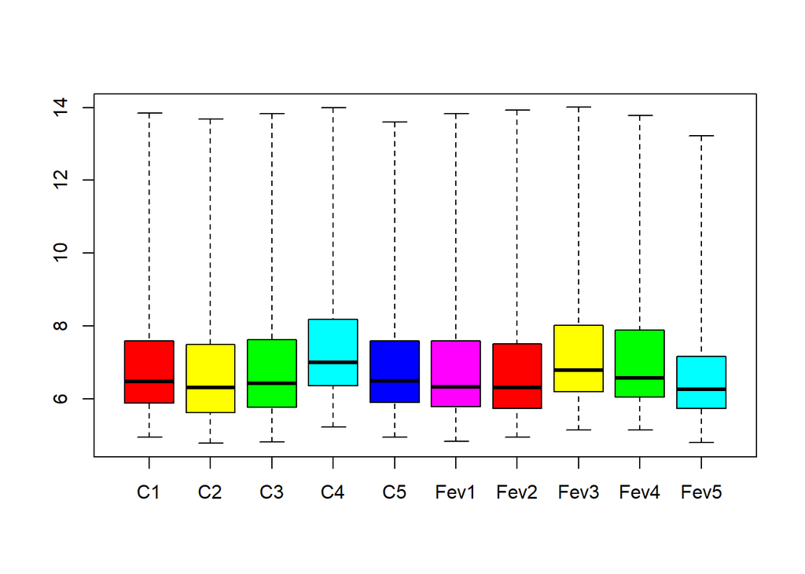

```r
boxplot(affyData, col=rainbow(6))
```

##Correlación de nuestras muestras. Muestra la correlación y cuales son las más parecidas entre ellas, mediante un heatmap.

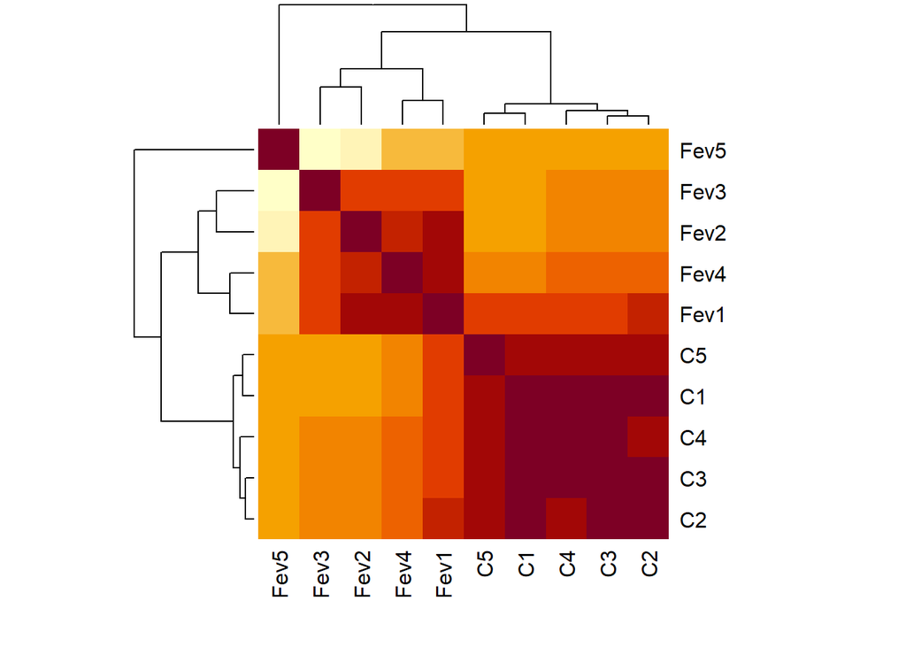

```r
heatmap(cor(exprs(affyData)), symm=T)
```

##Dendograma Ns muestra cual las relaciones más cercanas de una manera más fácil.

```r
corClust = pvclust(exprs(affyData), nboot=1, method.dist="correlation")
```

```
## Bootstrap (r = 0.5)... Done.
## Bootstrap (r = 0.6)... Done.
## Bootstrap (r = 0.7)... Done.
## Bootstrap (r = 0.8)... Done.
## Bootstrap (r = 0.9)... Done.
## Bootstrap (r = 1.0)... Done.
## Bootstrap (r = 1.1)... Done.
## Bootstrap (r = 1.2)... Done.
## Bootstrap (r = 1.3)... Done.
## Bootstrap (r = 1.4)... Done.
```

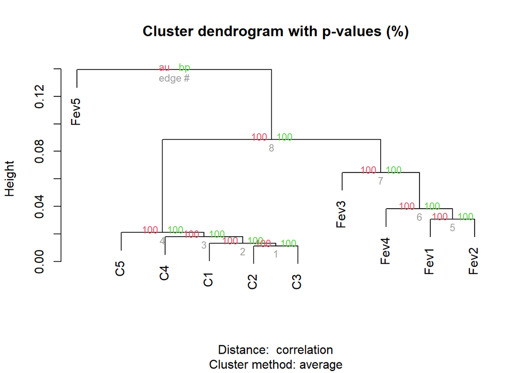

```r
plot(corClust)
```

##Análisis de componentes Un análisis de componentes principales nos permite ver grupos entre las muestras ubicadas de diferente color.

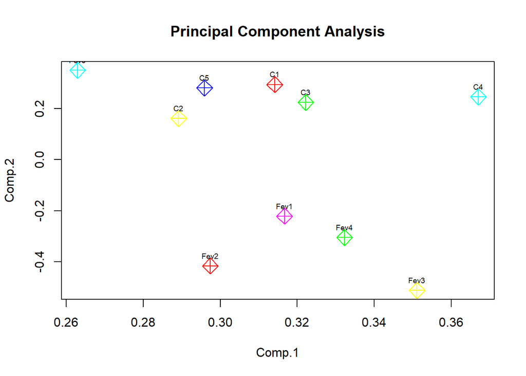

```r
pca <- princomp(exprs(affyData))
plot(pca$loadings, main="Principal Component Analysis", col=rainbow(6),  pch=9, cex=2)
text(pca$loadings, colnames(exprs(affyData)), pos=3, cex=0.6)
```

##Normalización La normalización es para evitar números negativos y para que nuestras muestras se ajusten a unos valores promedio.

```r
norman <- rma(affyData)
```

```
## Background correcting
## Normalizing
## Calculating Expression
```

```r
normalize.AffyBatch.methods()
```

```
## [1] "constant"         "contrasts"        "invariantset"     "loess"
## [5] "methods"          "qspline"          "quantiles"        "quantiles.robust"
## [9] "vsn"
```

##Boxplot de la expresión normalizada. Una buena estrategia de normalizado debe controlar la variabilidad a lo largo del rango de valores de expresión. Por ejemplo, no queremos que los genes altamente expresados cambien en promedio más que los genes de expresión media. Podemos revisar esto con la siguiente gráfica

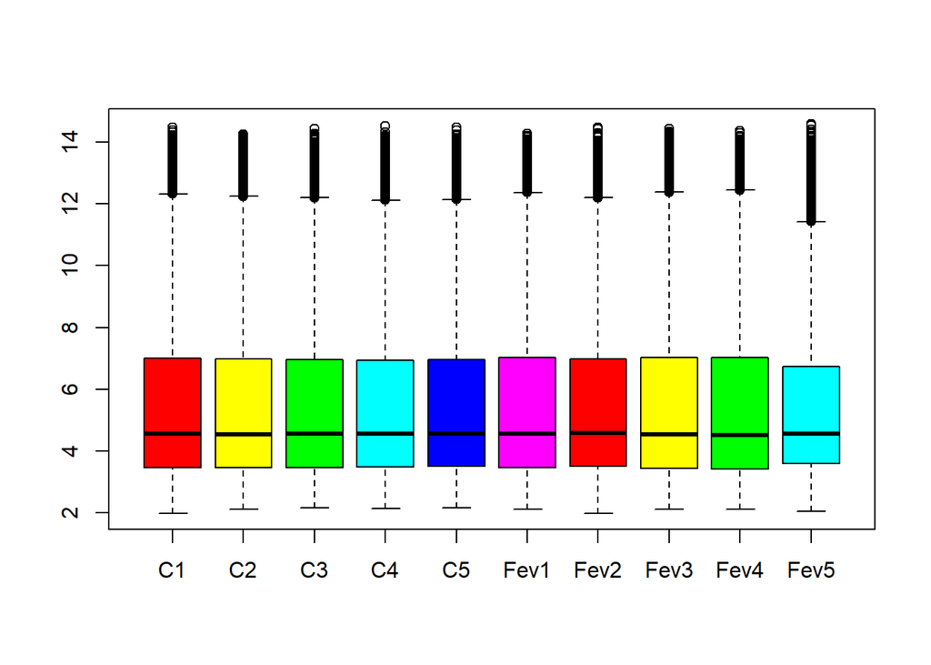

```r
boxplot(data.frame(exprs(norman)), col=rainbow(6))
```

```r
corClustAfter <- pvclust(exprs(norman), nboot=1, method.dist="correlation")
```

```
## Bootstrap (r = 0.5)... Done.
## Bootstrap (r = 0.6)... Done.
## Bootstrap (r = 0.7)... Done.
## Bootstrap (r = 0.8)... Done.
## Bootstrap (r = 0.9)... Done.
## Bootstrap (r = 1.0)... Done.
## Bootstrap (r = 1.1)... Done.
## Bootstrap (r = 1.2)... Done.
## Bootstrap (r = 1.3)... Done.
## Bootstrap (r = 1.4)... Done.
```

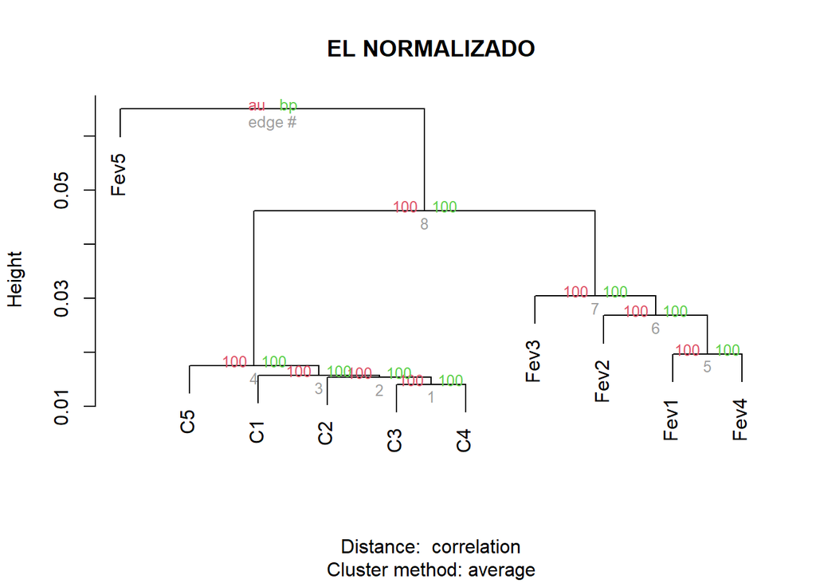

```r
plot(corClustAfter, main="EL NORMALIZADO")
```

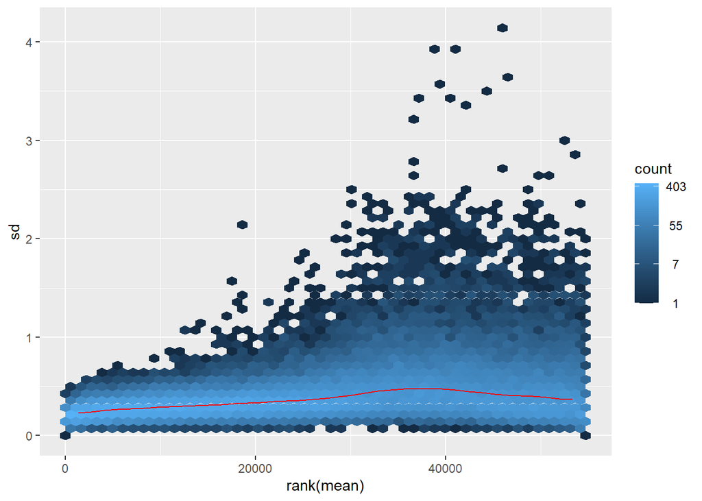

```r
meanSdPlot(exprs(norman)) #Promedio de la expresión diferencial normalizada.
```

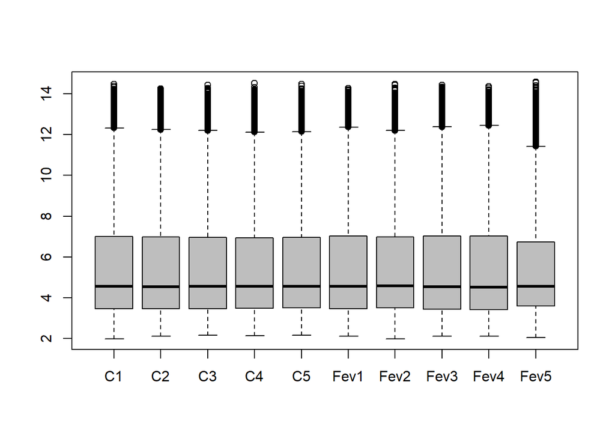

```r
boxplot(data.frame(exprs(norman)), col="grey")
```

##Guardar la expresión normalizada Con este script ae guarda la expresión normalizada en la misma carpeta donde estan las muestras.

```r
write.exprs(norman, file="expr_normalizadaomg2.txt")
save(norman,file="aa.Rdata")
```

se vuelve a leer el archivo generado anteriormente

```r
try <- read.table("expr_normalizadaomg2.txt", header=TRUE, row.names=1)
head(try)
```

```
##                     C1        C2        C3        C4       C5      Fev1
## 1007_PM_s_at  7.150570  7.203812  6.855695  7.386815 7.119978  6.316704
## 1053_PM_at    7.067271  7.270050  7.432049  6.966037 6.952304  7.888679
## 117_PM_at    10.417998 10.333154 10.688239 10.090554 9.999675 10.133974
## 121_PM_at     6.597516  5.847631  5.891409  6.088425 5.858593  6.293973
## 1255_PM_g_at  3.022971  2.891521  2.493966  2.855103 3.250204  2.933706
## 1294_PM_at    9.037481  9.182859  9.128782  9.089490 9.038090  9.482634
##                  Fev2     Fev3      Fev4      Fev5
## 1007_PM_s_at 5.705807 6.669157  6.124667  6.207095
## 1053_PM_at   7.788013 8.521410  7.808153  7.241119
## 117_PM_at    9.097331 7.739225 10.607159 11.185888
## 121_PM_at    6.803235 6.241250  6.116950  6.763421
## 1255_PM_g_at 3.210367 2.769677  2.770895  3.370104
## 1294_PM_at   9.292009 8.877459  9.047843  9.518003
```

##Cálculo de la expresión diferencial Primero asignamos los nombres de nuestro factores en un vector llamado types, estos son los que se quieren comprar dentro del diseño experimental. También se hace el diseño experimental, donde se crea primero el diseño de nuestra matriz con las especificaciones dadas.

```r
types <- factor(c("Fev","Fev","Fev", "Fev", "Fev", "C", "C","C","C", "C"))
types
```

```
##  [1] Fev Fev Fev Fev Fev C   C   C   C   C
## Levels: C Fev
```

```r
design <- model.matrix(~ 0+types)
colnames(design) <- levels(types)
design
```

```
##    C Fev
## 1  0   1
## 2  0   1
## 3  0   1
## 4  0   1
## 5  0   1
## 6  1   0
## 7  1   0
## 8  1   0
## 9  1   0
## 10 1   0
## attr(,"assign")
## [1] 1 1
## attr(,"contrasts")
## attr(,"contrasts")$types
## [1] "contr.treatment"
```

```r
contMatrix <- makeContrasts(Fev-C, levels=design)
contMatrix
```

```
##       Contrasts
## Levels Fev - C
##    C        -1
##    Fev       1
```

Luego ajustamos nuestos datos de expresión a un modelo lineal, de ahí se calculan coeficientes estimados y errores estandar los cuales nos diran si son o no son significativos los datos. eBayes nos ordena los datos para saber cuál aumento en su expresión y cuál disminiyó. topTable nos permite tomar los 20 genes que cambiaron su expresión diferencial y finalmente lo colocamos en un volcano plot.

```r
fit  <- lmFit(try,design)
fit2 <- contrasts.fit(fit,contMatrix)
fit2 <- eBayes(fit2)

topTable(fit2, number=20, sort.by="p")
```

```
##                    logFC   AveExpr         t      P.Value    adj.P.Val
## 219313_PM_at    3.209453  5.499899  19.82946 9.143222e-11 5.002714e-06
## 202779_PM_s_at -2.599265  8.357372 -14.13830 5.126576e-09 8.122977e-05
## 218542_PM_at   -4.535467  6.179276 -13.85655 6.489640e-09 8.122977e-05
## 219785_PM_s_at -2.472901  5.452823 -13.73943 7.166884e-09 8.122977e-05
## 209231_PM_s_at -1.922656  7.043860 -13.69822 7.422989e-09 8.122977e-05
## 202411_PM_at   -5.459391 10.122322 -13.31071 1.037426e-08 9.460458e-05
## 227112_PM_at    1.691878  8.401489  12.99178 1.375390e-08 1.075064e-04
## 220118_PM_at   -1.720494  5.683780 -12.32472 2.530951e-08 1.731012e-04
## 219911_PM_s_at -2.689928  5.596006 -11.99277 3.465138e-08 1.784597e-04
## 222680_PM_s_at -4.438534  6.287573 -11.98136 3.503220e-08 1.784597e-04
## 210052_PM_s_at -3.720262  6.625896 -11.95649 3.587786e-08 1.784597e-04
## 202589_PM_at   -4.293229  8.994041 -11.85856 3.942768e-08 1.797738e-04
## 225834_PM_at   -2.961044  6.984316 -11.69500 4.622501e-08 1.813821e-04
## 1553842_PM_at   2.486719  6.508365  11.65341 4.814757e-08 1.813821e-04
## 232352_PM_at    1.716141  4.982953  11.55637 5.297473e-08 1.813821e-04
## 225330_PM_at    2.015209  7.902265  11.45322 5.868200e-08 1.813821e-04
## 201761_PM_at   -1.914575  9.734587 -11.45182 5.876376e-08 1.813821e-04
## 213351_PM_s_at  1.757326  7.903098  11.43645 5.967063e-08 1.813821e-04
## 221436_PM_s_at -3.293484  5.973636 -11.32521 6.669830e-08 1.920736e-04
## 214321_PM_at    4.226100  6.233234  11.23147 7.331174e-08 1.937921e-04
##                        B
## 219313_PM_at   13.873526
## 202779_PM_s_at 10.788611
## 218542_PM_at   10.591384
## 219785_PM_s_at 10.507864
## 209231_PM_s_at 10.478255
## 202411_PM_at   10.194205
## 227112_PM_at    9.952513
## 220118_PM_at    9.422615
## 219911_PM_s_at  9.145970
## 222680_PM_s_at  9.136301
## 210052_PM_s_at  9.115192
## 202589_PM_at    9.031562
## 225834_PM_at    8.890098
## 1553842_PM_at   8.853760
## 232352_PM_at    8.768407
## 225330_PM_at    8.676770
## 201761_PM_at    8.675521
## 213351_PM_s_at  8.661785
## 221436_PM_s_at  8.561757
## 214321_PM_at    8.476603
```

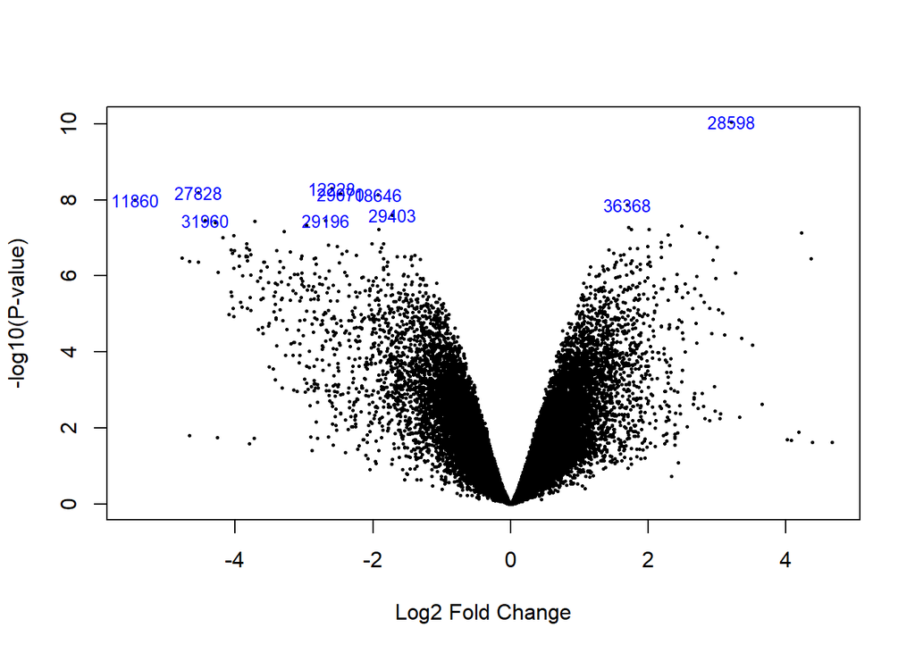

```r
volcanoplot(fit2, highlight=10, names=fit2$genes$Gene.ID)
```

#Control y Fiebre Hemorragica. ## Primero cargamos los archivos.

```r
setwd("C:/Users/HP/Documents/6to semestre/Genómica/Proyecto final/Proyecto/Celulas/")

list.files()
```

```
##  [1] "C1.CEL"                   "C2.CEL"
##  [3] "C3.CEL"                   "C4.CEL"
##  [5] "C5.CEL"                   "COV1.CEL"
##  [7] "COV2.CEL"                 "COV3.CEL"
##  [9] "COV4.CEL"                 "COV5.CEL"
## [11] "expr_normalizadaomg.txt"  "expr_normalizadaomg2.txt"
## [13] "expr_normalizadaomg3.txt" "FD1.CEL"
## [15] "FD2.CEL"                  "FD3.CEL"
## [17] "FD4.CEL"                  "FD5.CEL"
## [19] "FH1.CEL"                  "FH2.CEL"
## [21] "FH3.CEL"                  "FH4.CEL"
## [23] "FH5.CEL"                  "norman.Rdata"
## [25] "pdata.txt"                "pdata2.txt"
## [27] "pdata3.txt"               "pdatacompleta.txt"
```

```r
pd <- read.table("pdata3.txt", header=TRUE, as.is=TRUE) #esta tabla se relizó en un archivo de texto.
pd
```

```
##    filename cell type name
## 1    C1.cel   er    C   C1
## 2    C2.cel   er    C   C2
## 3    C3.cel   er    C   C3
## 4    C4.cel   er    C   C4
## 5    C5.cel   er    C   C5
## 6   FH1.cel   er   Fh  Fh1
## 7   FH2.cel   er   Fh  Fh2
## 8   FH3.cel   er   Fh  Fh3
## 9   FH4.cel   er   Fh  Fh4
## 10  FH5.cel   er   Fh  Fh5
```

```r
##Converción a un archivo AffyData.
affyData <- ReadAffy(filenames=pd$filename)
class(affyData)
```

```
## [1] "AffyBatch"
## attr(,"package")
## [1] "affy"
```

```r
pData(affyData) <- pd
sampleNames(affyData) = pd$name
affyData
```

```
## AffyBatch object
## size of arrays=744x744 features (23 kb)
## cdf=HT_HG-U133_Plus_PM (54715 affyids)
## number of samples=10
## number of genes=54715
## annotation=hthgu133pluspm
## notes=
```

##Analisis de calidad.

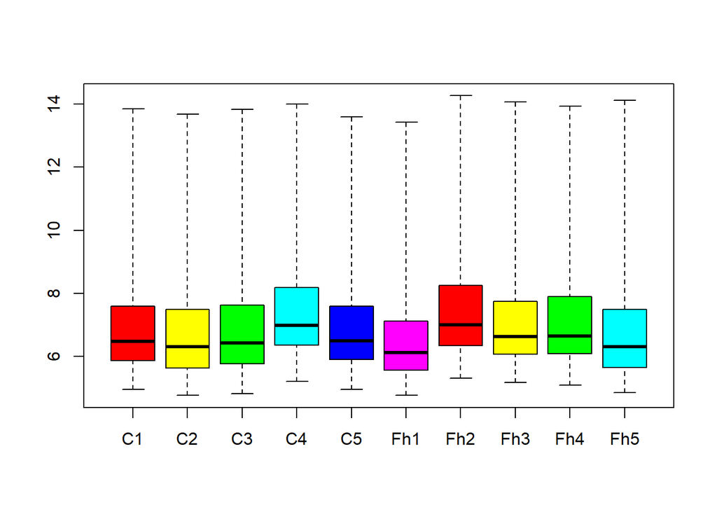

```r
boxplot(affyData, col=rainbow(6))
```

##Correlación de nuestras muestras.

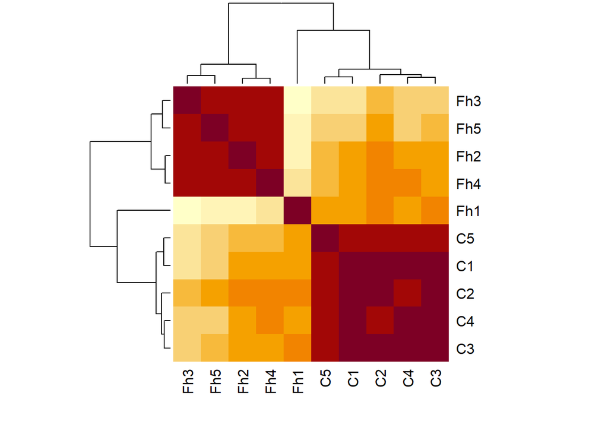

```r
heatmap(cor(exprs(affyData)), symm=T)
```

##Dendograma

```r
corClust = pvclust(exprs(affyData), nboot=1, method.dist="correlation")
```

```
## Bootstrap (r = 0.5)... Done.
## Bootstrap (r = 0.6)... Done.
## Bootstrap (r = 0.7)... Done.
## Bootstrap (r = 0.8)... Done.
## Bootstrap (r = 0.9)... Done.
## Bootstrap (r = 1.0)... Done.
## Bootstrap (r = 1.1)... Done.
## Bootstrap (r = 1.2)... Done.
## Bootstrap (r = 1.3)... Done.
## Bootstrap (r = 1.4)... Done.
```

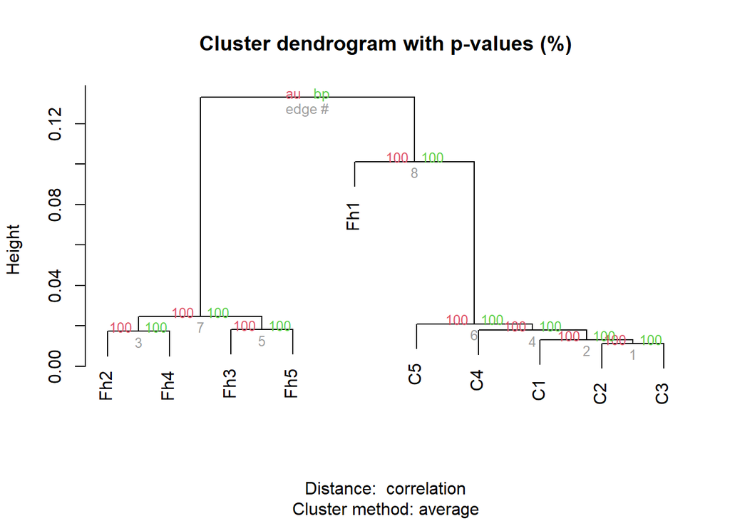

```r
plot(corClust)
```

##Analisis de componentes

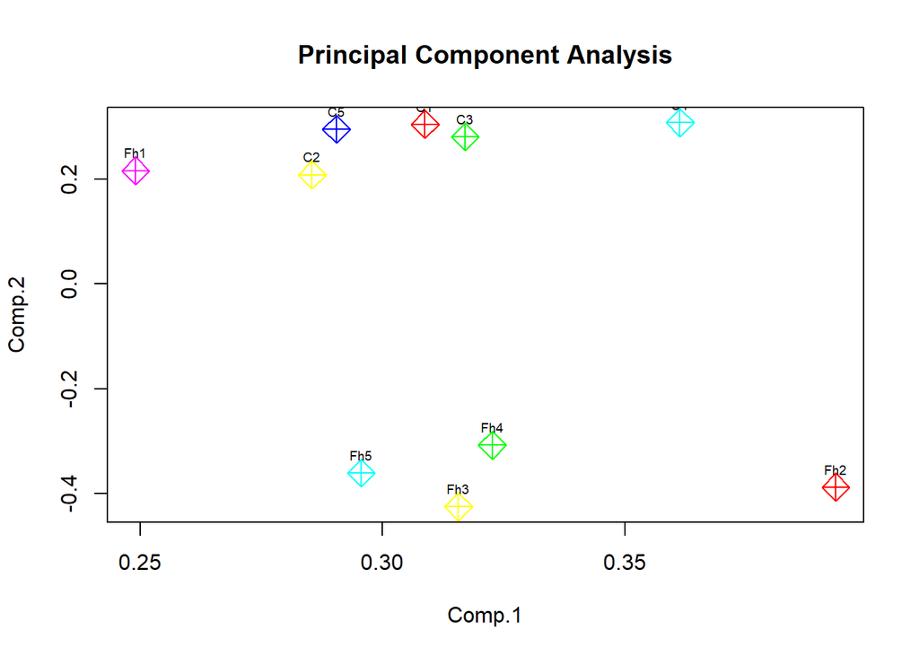

```r
pca <- princomp(exprs(affyData))
plot(pca$loadings, main="Principal Component Analysis", col=rainbow(6),  pch=9, cex=2)
text(pca$loadings, colnames(exprs(affyData)), pos=3, cex=0.6)
```

##Normalización

```r
norman <- rma(affyData)
```

```
## Background correcting
## Normalizing
## Calculating Expression
```

```r
normalize.AffyBatch.methods()
```

```
## [1] "constant"         "contrasts"        "invariantset"     "loess"
## [5] "methods"          "qspline"          "quantiles"        "quantiles.robust"
## [9] "vsn"
```

##Boxplot de la expresión normalizada.

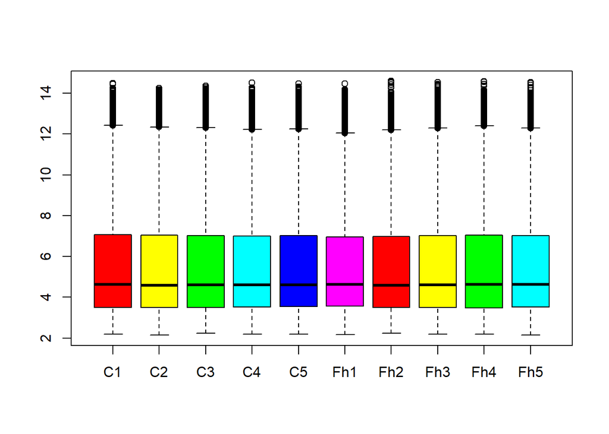

```r
boxplot(data.frame(exprs(norman)), col=rainbow(6))
```

```r
corClustAfter <- pvclust(exprs(norman), nboot=1, method.dist="correlation")
```

```
## Bootstrap (r = 0.5)... Done.
## Bootstrap (r = 0.6)... Done.
## Bootstrap (r = 0.7)... Done.
## Bootstrap (r = 0.8)... Done.
## Bootstrap (r = 0.9)... Done.
## Bootstrap (r = 1.0)... Done.
## Bootstrap (r = 1.1)... Done.
## Bootstrap (r = 1.2)... Done.
## Bootstrap (r = 1.3)... Done.
## Bootstrap (r = 1.4)... Done.
```

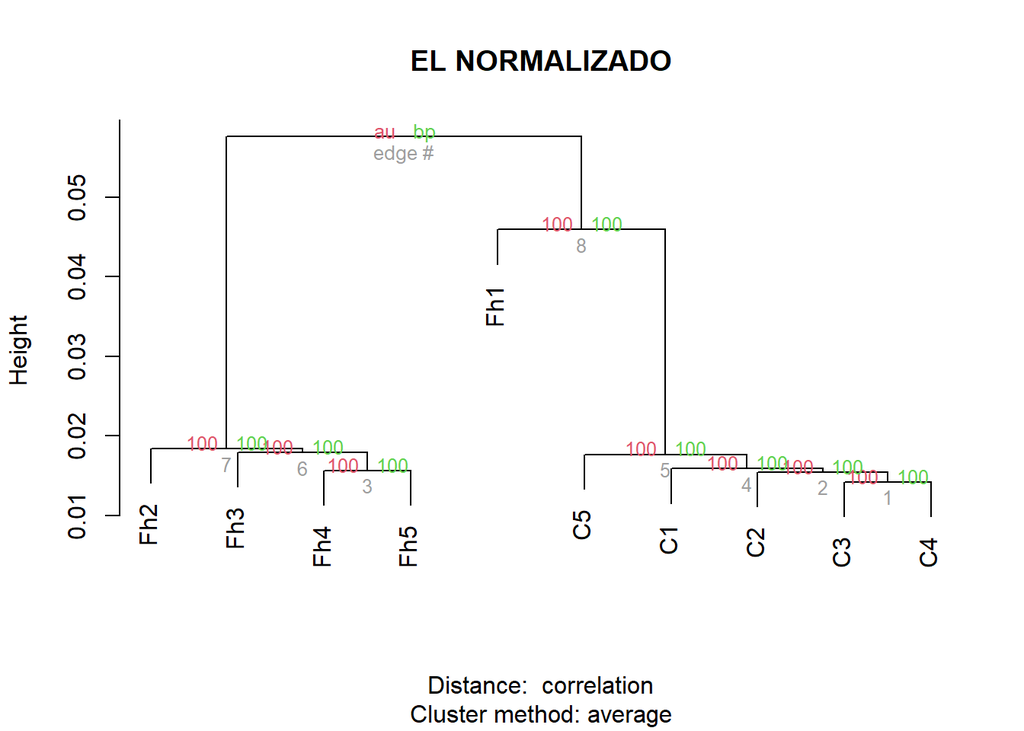

```r
plot(corClustAfter, main="EL NORMALIZADO")
```

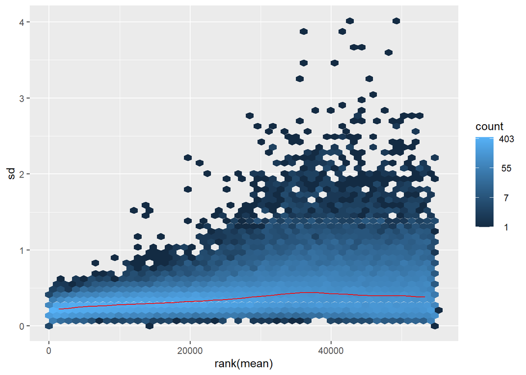

```r
meanSdPlot(exprs(norman))
```

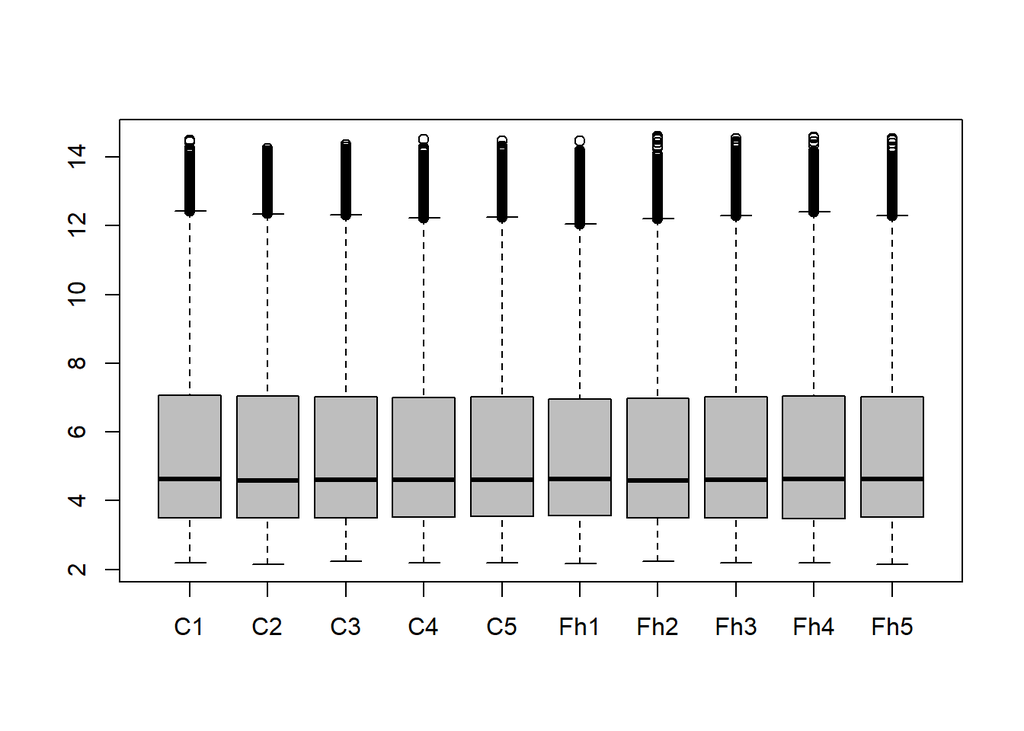

```r
boxplot(data.frame(exprs(norman)), col="grey")
```

##Guardar la expresión normalizada

```r
write.exprs(norman, file="expr_normalizadaomg3.txt")
save(norman,file="norman.Rdata")
```

```r
try <- read.table("expr_normalizadaomg3.txt", header=TRUE, row.names=1)
head(try)
```

```
##                     C1        C2        C3        C4       C5       Fh1
## 1007_PM_s_at  7.408521  7.116476  6.923872  7.443319 7.193836  5.542826
## 1053_PM_at    7.216689  7.434635  7.546547  7.069889 7.171648  7.228008
## 117_PM_at    10.401537 10.309852 10.669145 10.113503 9.969072 11.221700
## 121_PM_at     6.568255  5.808958  5.946838  6.010040 5.739992  5.851997
## 1255_PM_g_at  3.005414  3.030829  2.741076  3.035035 3.293714  2.924163
## 1294_PM_at    9.051264  9.207878  9.155861  9.094845 9.053075 10.112302
##                   Fh2      Fh3      Fh4      Fh5
## 1007_PM_s_at 6.023431 5.236231 6.182789 5.661680
## 1053_PM_at   8.379080 8.506115 7.718364 7.909809
## 117_PM_at    8.207676 7.616668 8.699800 8.542888
## 121_PM_at    6.098036 5.927162 6.016991 6.044602
## 1255_PM_g_at 2.807345 3.277977 2.926623 3.133058
## 1294_PM_at   8.950244 8.706378 9.147303 8.906935
```

##Cálculo de la expresión diferencial

```r
types <- factor(c("Fh","Fh","Fh", "Fh", "Fh", "C", "C","C","C", "C"))
types
```

```
##  [1] Fh Fh Fh Fh Fh C  C  C  C  C
## Levels: C Fh
```

```r
design <- model.matrix(~ 0+types)
colnames(design) <- levels(types)
design
```

```
##    C Fh
## 1  0  1
## 2  0  1
## 3  0  1
## 4  0  1
## 5  0  1
## 6  1  0
## 7  1  0
## 8  1  0
## 9  1  0
## 10 1  0
## attr(,"assign")
## [1] 1 1
## attr(,"contrasts")
## attr(,"contrasts")$types
## [1] "contr.treatment"
```

```r
contMatrix <- makeContrasts(Fh-C, levels=design)
contMatrix
```

```
##       Contrasts
## Levels Fh - C
##     C      -1
##     Fh      1
```

##Ajuste a un modelo lineal y volcano plot.

```r
fit  <- lmFit(try,design) #ajustar modelos lineales a nuestros datos de expresión
fit2 <- contrasts.fit(fit,contMatrix) #coeficinetes estimados
fit2 <- eBayes(fit2) #les das como un estimado que nos dira si son significativamente diferent

topTable(fit2, number=20, sort.by="p")
```

```
##                     logFC   AveExpr         t      P.Value    adj.P.Val
## 224454_PM_at    -2.750855  5.910925 -18.48134 2.695917e-10 1.237552e-05
## 227747_PM_at     2.147816  9.406222  17.22538 6.181218e-10 1.237552e-05
## 227425_PM_at     2.337897  7.237437  17.08928 6.785447e-10 1.237552e-05
## 228486_PM_at    -2.709175  8.020718 -16.57760 9.695733e-10 1.326255e-05
## 202760_PM_s_at  -2.650150  8.386453 -16.09769 1.367790e-09 1.365004e-05
## 219053_PM_s_at   1.893929  7.938092  15.97405 1.496852e-09 1.365004e-05
## 202759_PM_s_at  -2.126389  9.083142 -15.73176 1.789509e-09 1.381821e-05
## 37384_PM_at      1.895682  8.658540  15.54639 2.054991e-09 1.381821e-05
## 203063_PM_at     1.988617  8.499931  15.23493 2.601542e-09 1.381821e-05
## 1560060_PM_s_at  1.969416  8.477479  15.12482 2.830705e-09 1.381821e-05
## 210724_PM_at     2.928792  7.926131  15.07743 2.935959e-09 1.381821e-05
## 227970_PM_at     2.039803  6.209204  15.03190 3.041052e-09 1.381821e-05
## 229789_PM_at     2.635123  6.699328  14.81203 3.608956e-09 1.381821e-05
## 232094_PM_at     2.863695  6.742514  14.76165 3.754552e-09 1.381821e-05
## 209457_PM_at    -3.718763  8.822671 -14.74647 3.799670e-09 1.381821e-05
## 1555274_PM_a_at -2.999451  6.575571 -14.66848 4.040781e-09 1.381821e-05
## 58916_PM_at     -3.011783  4.858599 -14.47818 4.701206e-09 1.471414e-05
## 212473_PM_s_at   2.933968 10.093298  14.44170 4.840619e-09 1.471414e-05
## 219892_PM_at     1.974052  8.051488  14.32427 5.320461e-09 1.532153e-05
## 225834_PM_at    -3.024427  6.978179 -13.95607 7.188596e-09 1.889367e-05
##                        B
## 224454_PM_at    13.47666
## 227747_PM_at    12.80873
## 227425_PM_at    12.73225
## 228486_PM_at    12.43708
## 202760_PM_s_at  12.14882
## 219053_PM_s_at  12.07270
## 202759_PM_s_at  11.92123
## 37384_PM_at     11.80328
## 203063_PM_at    11.60093
## 1560060_PM_s_at 11.52812
## 210724_PM_at    11.49657
## 227970_PM_at    11.46614
## 229789_PM_at    11.31754
## 232094_PM_at    11.28311
## 209457_PM_at    11.27270
## 1555274_PM_a_at 11.21902
## 58916_PM_at     11.08653
## 212473_PM_s_at  11.06088
## 219892_PM_at    10.97779
## 225834_PM_at    10.71170
```

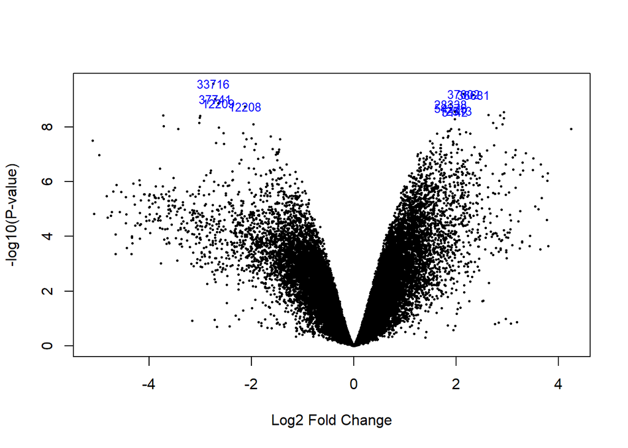

```r
volcanoplot(fit2, highlight=10)
```

#Parte 2. Fácil.

Tenemos una base de datos con la respuesta de 60 personas de 60 preguntas sobre gustos raros o preguntas X. Primero cargamos la librería igraph, luego se subió la base de datos. Todas las preguntas se respondían con sí o no

```r
library(igraph)
pla <- read.csv("C:/Users/HP/Documents/6to semestre/Genómica/Proyecto final/a - a.csv")
```

Les dimos nombres a las filas. La volteamos y la convertimos en una matriz para que sea posible el análisis.

```r
rownames(pla)<-pla[,1]
pla<-pla[,-1]
pla<-t(as.matrix(pla))
pla
```

[output not shown]

[output cut: 989 more lines]

```
## Â.Te.gusta.Taylor.Swift.                                1
## Â.Ligaste.con.un.extranjero.                            0
## Â.Te..has.pintado.el.cabello.                           0
## Â.Eres.rar..                                            0
## Â.Tienes.esperanza.de.pasar.el.semestre.                1
## Â.Eres.incomprendid..                                   1
## Â.Eres.el..la..morr..de.los.plumones.                   0
## Â.Te.consideras.original.                               1
## Â.Te.han.dicho.que.eres.arte.                           0
## Â.Escuchas.mÃºsica.clÃ.sica.                            0
## Â.Eres.fresa.                                           0
## Â.Fuiste.a.escuela.privada.                             0
## Â.Eres.medio.egÃ³latra.                                 1
## Â.Escapaste.de.latinoamÃ.rica.                          0
## Â.Tus.ex.hablan.mal.de.ti.                              0
```

Calculamos diferentes coeficientes de correlación de la base de datos para saber la relación de cada persona de acuerdo a sus gustazos.

```r
aa<-cor(pla[,-1], method="pearson") #calcular coeficiente de correclación
bb <- cor(pla[,-1], method="kendall")
cc <- cor(pla[,-1], method="spearman")
```

Finalmente realizamos la red de cada uno de los coeficientes de correlación para la futura identificación de clusters, de esta forma, se agruprían a las personas con mayor cantidad de respuestas en común

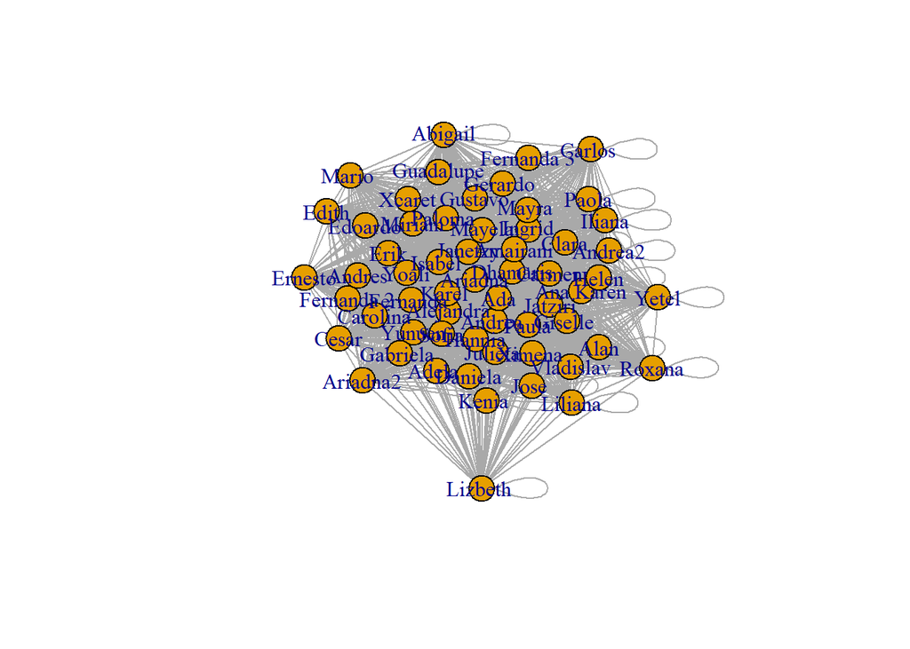

```r
red1<-graph_from_adjacency_matrix(aa, mode="undirected", weighted=T)
plot(red1)
```

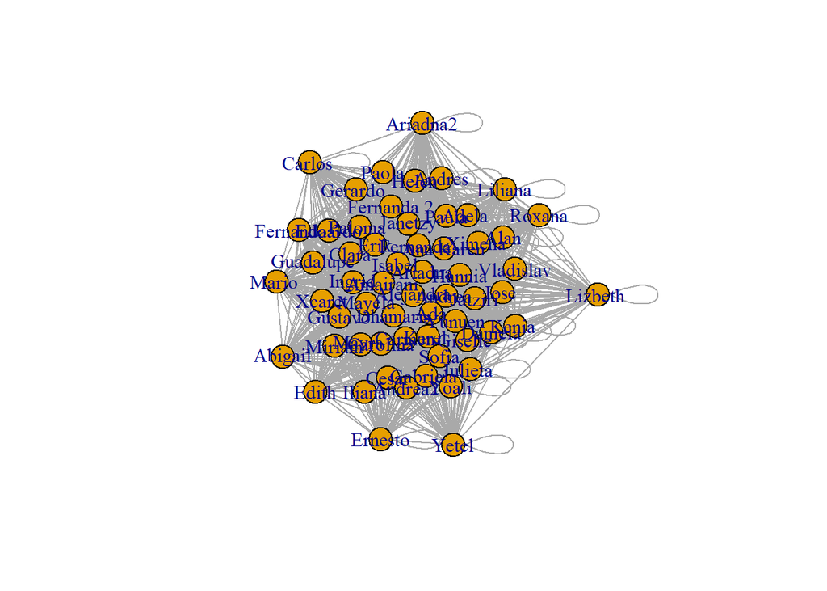

```r
red2<-graph_from_adjacency_matrix(bb, mode="undirected", weighted=T)
plot(red2)
```

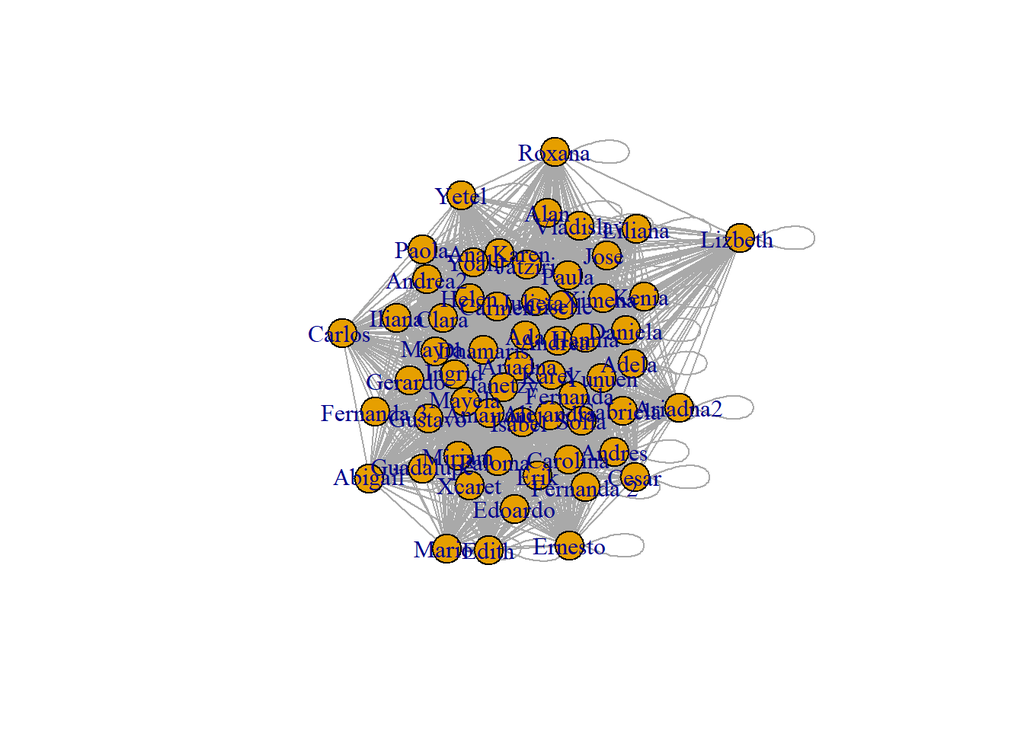

```r
netw<-graph_from_adjacency_matrix(cc, mode="undirected", weighted=T)
plot(netw)
```

Con base en los coeficientes de correlación, se establece un umbral que permitirá realizar los clusters, en este caso y con base en los resultados de correlación, se delimitó a 0.1

```r
diag(aa) <- 0
umbral <- 0.1
ad <- ifelse(aa > umbral, 0,1)
View(ad)
```

Se crean las redes con base en el umbral seleccionado y distintos métodos de clusterización

```r
red3<-graph_from_adjacency_matrix(ad, mode="undirected")
red3
```

```
## IGRAPH 3d09d35 UN-- 59 409 --
## + attr: name (v/c)
## + edges from 3d09d35 (vertex names):
##  [1] Ximena --Ximena     Ximena --Yetel      Ximena --Gustavo
##  [4] Ximena --Edith      Ximena --Ariadna    Ximena --Guadalupe
##  [7] Ximena --Miriam     Ximena --Mayra      Ximena --Ariadna2
## [10] Ximena --Edoardo    Ximena --Ernesto    Andrea --Andrea
## [13] Andrea --Carlos     Andrea --Gerardo    Andrea --Abigail
## [16] Andrea --Mario      Andrea --Ariadna2   Iliana --Iliana
## [19] Iliana --Carlos     Iliana --Fernanda   Iliana --Cesar
## [22] Iliana --Vladislav  Iliana --Roxana     Iliana --Jose
## + ... omitted several edges
```

```r
clust1<- label.propagation.community(red3)
clust1
```

```
## IGRAPH clustering label propagation, groups: 59, mod: 0.12
## + groups:
##   $`1`
##   [1] "Ximena "
##
##   $`2`
##   [1] "Andrea "
##
##   $`3`
##   [1] "Iliana"
##
##   $`4`
##   + ... omitted several groups/vertices
```

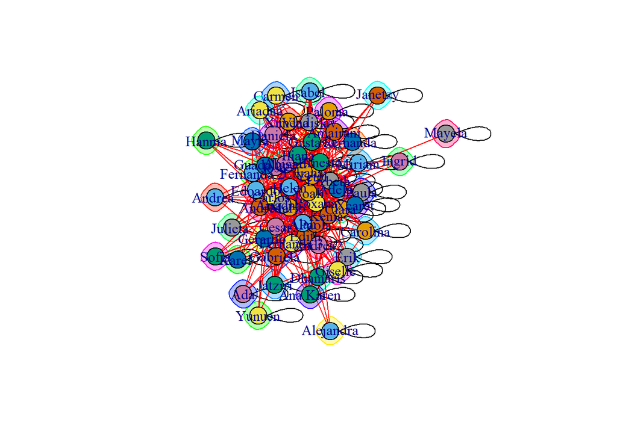

```r
plot (clust1,red3)
```

```r
clust2<- cluster_edge_betweenness(red3)
clust2
```

```
## IGRAPH clustering edge betweenness, groups: 48, mod: 0.13
## + groups:
##   $`1`
##   [1] "Ximena "
##
##   $`2`
##   [1] "Andrea "
##
##   $`3`
##   [1] "Iliana"
##
##   $`4`
##   + ... omitted several groups/vertices
```

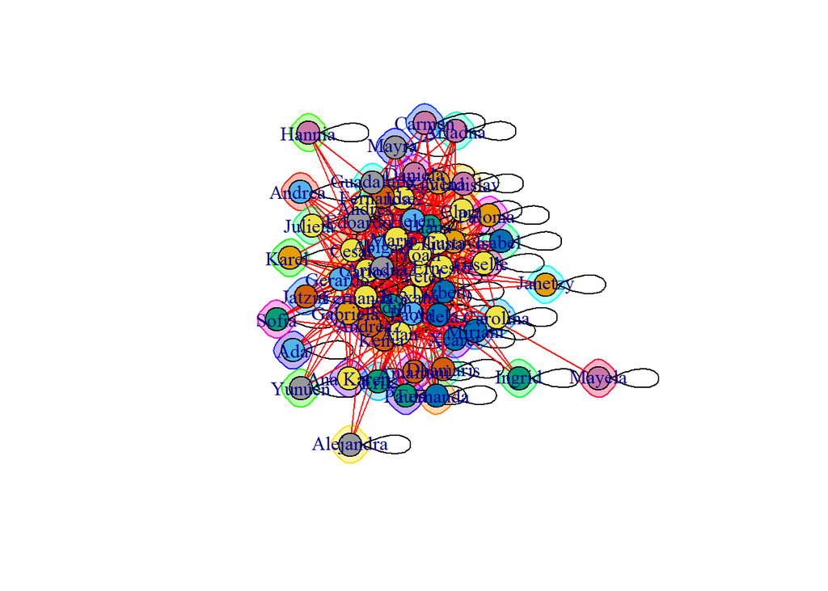

```r
plot(clust2,red3)
```

```r
clust3<-cluster_walktrap(red3)
clust3
```

```
## IGRAPH clustering walktrap, groups: 10, mod: 0.12
## + groups:
##   $`1`
##    [1] "Andrea "    "Carlos "    "Kenia "     "Cesar"      "Roxana"
##    [6] "Gerardo "   "Edith"      "Lizbeth "   "Karel "     "Paola"
##   [11] "Julieta "   "Dhamaris"   "Guadalupe"  "Abigail"    "Erik"
##   [16] "Miriam"     "Jatziri"    "Gabriela "  "Paula"      "Mario "
##   [21] "Alan"       "Ana Karen"  "Fernanda 3" "Xcaret"     "Daniela"
##   [26] "Ariadna2"   "Andres"     "Andrea2"    "Edoardo"
##
##   $`2`
##    [1] "Ximena "    "Iliana"     "Fernanda "  "Vladislav"  "Yetel"
##   + ... omitted several groups/vertices
```

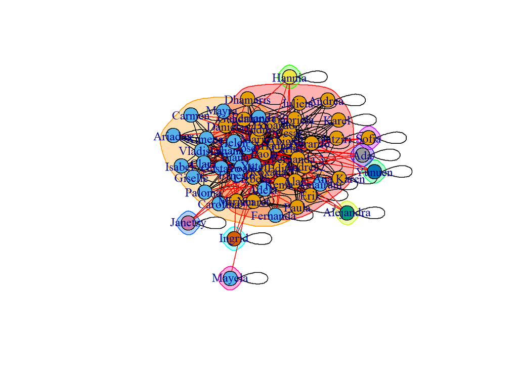

```r
plot(clust3,red3)
```

```r
clust4<- leading.eigenvector.community(red3) #este es el bueno.
clust4
```

```
## IGRAPH clustering leading eigenvector, groups: 10, mod: 0.23
## + groups:
##   $`1`
##   [1] "Ximena "  "Kenia "   "Gustavo"  "Abigail"  "Xcaret"   "Amairani"
##   [7] "Ariadna2" "Adela "
##
##   $`2`
##   [1] "Iliana"     "Lizbeth "   "Fernanda 2" "Mayra "     "Daniela"
##   [6] "Helen"      "Edoardo"
##
##   $`3`
##    [1] "Vladislav" "Jose "     "Clara"     "Dhamaris"  "Carmen"    "Mario "
##   + ... omitted several groups/vertices
```

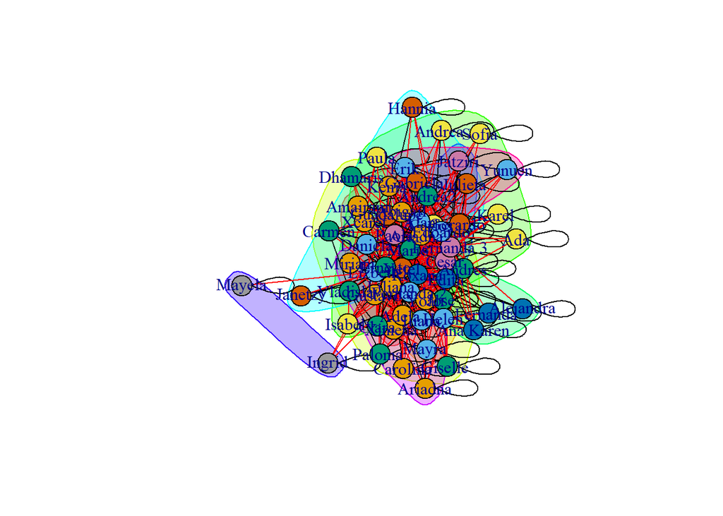

```r
plot(clust4,red3)
```